# Assignment 2: **Image stitching** of two images

## Introduction

In this notebook I have collected the solution for the second assignment, whose purpose is to apply stitching to two images selected by me.

To carry out the exercise I used the **OpenCV** library in the version `3.4.2.17`.

```python
!pip install opencv_contrib_python==3.4.2.17 --force-reinstall
```

```python
import cv2 as cv
print(cv.__version__)
import numpy as np
from matplotlib import pyplot as plt

# Setting image dimensions in visualization
plt.rcParams['figure.figsize'] = [15, 5]
```

```
3.4.2
```

```python
# Images Importing
im1 = cv.imread('/path/to/alcazar1.jpg', 0)
im2 = cv.imread('/path/to/alcazar2.jpg', 0)
```

```python
im1.shape
```

```
(960, 1280)
```

## Key Points Search

Through **SIFT** (Scale-Invariant Feature Transform) I searched for the notable points (discriminative and non-homogeneous regions) of the two imported images. These are fundamental for applying the stitching on the images as they are invariant under rotation, that is, even if the image rotates, there are still key points.

```python
# SIFT Instantiation
sift = cv.xfeatures2d.SIFT_create()
```

```python
# Image 1's Key Points and Descriptors Search
kps1, features1 = sift.detectAndCompute(im1, None)

# Image 2's Key Points and Descriptors Search
kps2, features2 = sift.detectAndCompute(im2, None)
```

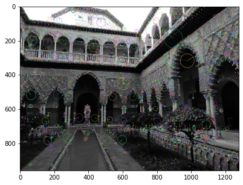

```python
# Image 1's Key Points Visualization
im1_kps = cv.drawKeypoints(im1, kps1, None,
                           flags = cv.DRAW_MATCHES_FLAGS_DRAW_RICH_KEYPOINTS)
plt.imshow(im1_kps)
```

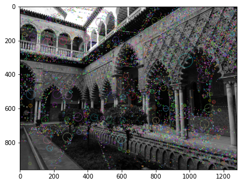

```python
# Image 2's Key Points Visualization
im2_kps = cv.drawKeypoints(im2, kps1, None,
                           flags = cv.DRAW_MATCHES_FLAGS_DRAW_RICH_KEYPOINTS)
plt.imshow(im2_kps)
```

## Intersection Points Search

In order to be able to join the two images, I then searched for their points in common through the `BFMatcher` object of *cv2*. This object allowed me to find the best matches by calling the `BFMatcher.match()` function; I then sorted the matches by distance, from closest to furthest away.

```python
# Brute Force Matching
bf = cv.BFMatcher(crossCheck = True)
matches = bf.match(features1, features2)

# Correspondences Sorting by Distance
matches = sorted(matches, key=lambda x: x.distance)
```

## `myHomography` Function Definition

To proceed with the union of the two images it was necessary to define a function which, having taken as input the key points of the two images and the intersection points, was able to calculate the homography of the images. This matrix is a transformation capable of mapping points of a plane to points of another plane, therefore the points of the second image with respect to the first.

The `myHomography(kps1, kps2, matches)` function generates the homography of the second image. It takes as input the key points of the first and second image and the matches found between them: generated a matrix of dimension *len(matches)*$\ =m\times 2$, which collects all the coordinates of the key points of the two images, calculates the homography through the function call `findHomography(pts2, pts1, cv.RANSAC, ransacReprojThreshold=2.0)` of *cv2*. In particular, given the *source* points `pts2` and the *destination* points `pts1`, the function determines a perspective transformation through the **Ransac** algorithm.

```python
def myHomography(kps1, kps2, matches):

  # Two Images' Key Points Coordinates Exctraction
  m = len(matches)
  pts1 = np.zeros((m, 1, 2), dtype=np.float32)
  pts2 = np.zeros((m, 1, 2), dtype=np.float32)

  for i in range(0,len(matches)):
    pts1[i] = kps1[matches[i].queryIdx].pt
    pts2[i] = kps2[matches[i].trainIdx].pt

  # Homography Development
  H, mask = cv.findHomography(pts2, pts1, cv.RANSAC, ransacReprojThreshold=2.0)

  return H
```

```python
homography1 = myHomography(kps1, kps2, matches)
```

```python
# Homography Matrix Visualization
homography1
```

```
array([[ 5.62964134e-01,  2.03971869e-02,  3.87889102e+02],
       [-2.02948150e-01,  8.14415971e-01,  1.16555178e+02],
       [-3.36008951e-04, -2.58491742e-05,  1.00000000e+00]])
```

## `myWarp` Function Definition

In order to be able to apply the homography generated in the previous point, I defined the function `myWarp(im, H)` which, given the matrix `H` and the image `im` as input, calculates the transformation of the latter.

In particular, before generating the transformation, the function must determine the size of the new image. To do this, assuming that the dimensions of the two images to be joined are the same, first of all determine the coordinates of 3 pivotal points in the transformation image:

1. *bottom right* (`br`), the last pixel on the **bottom right**;
2. *top right* (`tr`), the last pixel on the **top right**;
3. *lower left* (`bl`), the first **lower left** pixel.

For each of the points it calculates the new coordinates transformed through the following calculation: $$(x',y')_{img_{dest}} = \Big(\frac{H_{1,1}\cdot \ x \ + \ H_{1,2}\cdot \ y \ + \ H_{1,3}}{H_{3,1}\cdot \ x \ + \ H_{3,2}\cdot \ y \ + \ H_{3,3}} \ , \frac{H_{2,1}\cdot \ x \ + \ H_{2,2}\cdot \ y \ + \ H_{2,3}}{H_{3,1}\cdot \ x \ + \ H_{3,2}\cdot \ y \ + \ H_{3,3}}\Big)$$ where $(x,y)_{img_{src}}$.

The width of the new image is given by $w = min(x'_{br},x'_{tr})$, as I know that in this excercise the transformed image will be placed to the right of the first image.

To determine the height of the transformed image, and therefore of the union of the two images, it may happen that:

- the original height `y` is lower than the transformed ordinate of the *bottom right* point $\mapsto$ in this case the height remains unchanged and therefore $h = y$;
- the original height `y` is lower than the transformed ordinate of the *bottom left* point but greater than the y transformed *bottom right* $\mapsto$ the new height is the minimum between the original height and the ordinate of the *bottom right* pixel, i.e. $h = min(y, x'_{br})$;
- the original height `y` is greater than both the transformed ordinates of the *bottom right* and *bottom left* points $\mapsto$ the height of the transformed image is equal to the minimum ordinate of the two points, i.e. $h = min(x'_{br}, x'_{bl})$.

The image `im`, the matrix `H` and the dimensions `w`, `h` previously calculated are passed as input to the `warpPerspective` function of *cv2* which calculates the perspective transformation of `im`.

```python
def myWarp(im, H):

  y = im.shape[0]
  x = im.shape[1]

  # ['br', 'tr', 'bl']
  pts = [(x,y), (x,0), (0,y)]
  pts_transf = []
  for p in pts:
    x_ = p[0]
    y_ = p[1]
    num_w = H[0,0]*x_ + H[0,1]*y_ + H[0,2]
    num_h = H[1,0]*x_ + H[1,1]*y_ + H[1,2]
    den = H[2,0]*x_ + H[2,1]*y_ + H[2,2]
    x1_ = int(num_w / den)
    y1_ = int(num_h / den)
    pts_transf.append((x1_, y1_))

  # Definition of New Image's Width and Height
  # w = min(br, tr)
  # h = min(y, bl, br)
  w = min(pts_transf[0][0], pts_transf[1][0])
  if ( (y > pts_transf[2][1] and y < pts_transf[0][1]) or
      (y < pts_transf[2][1] and y < pts_transf[0][1]) ):
    h = y
  elif y < pts_transf[2][1] and y > pts_transf[0][1]:
    h = min(y, pts_transf[0][1])
  else:
    h = min(pts_transf[2][1], pts_transf[0][1])

  # Generation New Image
  im_out = cv.warpPerspective(im, H, (w, h))

  return im_out
```

```python
# Perspective Transformation of Image 2
im_warped = myWarp(im2, homography1)
```

[figure not shown]

```python
plt.imshow(im_warped, cmap='gray')
```

The image above represents the perspective transformation that has been applied to the right image in order to proceed with the image stitching: the `im1` image will fill in the black spaces on the left side of the `im_warped` image.

## `myCollage` Function Definition

As the last phase of the assignment I implemented the function `myCollage(im1, im2)` which, taking the original image on the left (`im1`) and the one on the right (`im2`) as input, generates the union of the two images in input.

For simplicity, I decided to collect in the function all the phases described in the previous paragraphs so that only through `myCollage(im1, im2)` it is possible to generate the merged image, without displaying the intermediate steps.

Therefore this function, following the function calls to `myHomography(kps1, kps2, matches)` (homography generation) and `myWarp(im2, H)` (transformation of the right image), is able to merge the two input images via `im_warped[0:im.shape[0], 0:im.shape[1]] = im`.

```python
def myCollage(im1, im2):

  # SIFT Instantiation
  sift = cv.xfeatures2d.SIFT_create()

  # Image 1's Key Points and Descriptors Search
  kps1, features1 = sift.detectAndCompute(im1, None)
  # Image 2's Key Points and Descriptors Search
  kps2, features2 = sift.detectAndCompute(im2, None)

  # Brute Force Matching
  bf = cv.BFMatcher(crossCheck = True)
  matches = bf.match(features1, features2)

  # Correspondences Sorting by Distance
  matches = sorted(matches, key=lambda x: x.distance)

  # Homography Matrix Generation
  H = myHomography(kps1, kps2, matches)

  # Perspective Transformation of Image 2
  im_warped = myWarp(im2, H)

  # Image Stitching Images 1 - 2
  im_warped[0:im1.shape[0], 0:im1.shape[1]] = im1

  return im_warped
```

```python
# Union Image Generation
imgs_stitched = myCollage(im1, im2)
```

[figure not shown]

```python
plt.imshow(imgs_stitched, cmap='gray')
```

The image above is the output of the `myCollage` function, the merger of the two initial images. As you can see, the black part that could be seen in the previous image has disappeared and has been filled with the image `im1`.